# IODS course project

Kristen Michelle Nader

# Introduction to Open Data Science - Course Project

# About the project

*Write a short description about the course and add a link to your GitHub repository here. This is an R Markdown (.Rmd) file so you should use R Markdown syntax.*

```r
date()
```

```
## [1] "Tue Nov 21 09:06:06 2023"
```

hello. its 6:11 Thursday November 2nd. I expect this course to be a refresher on topics I am already familiar with. I found this course on sisu. Im looking forward to working with new data, using new visualizing techniques and some multivariate techniques. Im interested in dealing with missing data

This is an Introduction to Open Data Science course where we will look at visualizing and analyzing open data with multivariate statistical methods and follow practices that encourage open reproducible science. Link to my Github: https://github.com/kris-nader/IODS-project

# Linear regression

*Describe the work you have done this week and summarize your learning.* *Summary of the week (completed work and learning)*

Chapter 2 consists of 2 parts:  
**-Data Wrangling.**In this section, we use survey data and make an analysis csv file using an R script (./data/create_learning2014.R).

**-Data Analysis.** In this section, we use the learning2014.csv file to do some exploratory analysis. This includes plots, linear regression, and qdiagnistic plots from our model nal model.

About the data: This data wad from a survey done to study the relationshop between learning approaches and student achievements in an intro course to statistics in finland which took place from 03-12-2014 to 10-01-2015.

## Part 1: data wrangling

It is a 183x60 data(before processing/data wrangling): 56 likert-scale variables on a scale of 1-5 3 continuous variables age, attitude, points 1 factor variable gender(male/female).

We have then created an analysis dataset for this chapter. We can then run the **./data/create_learning2014.R** script which results in the **learningdata2014.csv** dataset in the same **data** directory. In this script, we create new variables based on the metadata hosted here: https://www.mv.helsinki.fi/home/kvehkala/JYTmooc/JYTOPKYS2-meta.txt and filter datapoints that have a points variable=0.

After filtering, we have 7 variables and 166 observations:

- Gender: Male or Female.
- Age: In years, ranging from 17 to 55.
- Attitude: Global attitude toward statistics ~Da+Db+Dc+Dd+De+Df+Dg+Dh+Di+Dj.
- deep: Deep approach. Calculated by averaging the likert scale from 1-5 scale of 3 techniques(Seeking meaning: d_sm Relating ideas:d_ri and Use of evidence:d_ue).
- surf: Surface approach valculated simialr to deep based on 3 columns(lack of purpose:su_lp, unrelated memorizing:su_um and syllabus boundness:su_sb.
- stra: Strategic approach, Calculated similar to deep(organized studying:st_os & time management:st_tm).
- points: total points on an exam.

In addition, a pre-made **learningdata2014.csv** is available https://raw.githubusercontent.com/KimmoVehkalahti/Helsinki-Open-Data-Science/master/datasets/learning2014.txt.

We can use the following command to create the dataset, under the impression that the original data is in the **data** directory.

```r
library(dplyr)
library(readr)
#source("./data/create_learning2014.R")
```

After some data wrangling, we have 7 variables: Age, attitude, points, gender, deep, stra, and surf. The gender variable is a character (M/F) and others are doubles.

```r
data=data.frame(read_csv('./data/learning2014.csv'))
str(data)
```

```
## 'data.frame':    166 obs. of  7 variables:
##  $ Age     : num  53 55 49 53 49 38 50 37 37 42 ...
##  $ attitude: num  3.7 3.1 2.5 3.5 3.7 3.8 3.5 2.9 3.8 2.1 ...
##  $ Points  : num  25 12 24 10 22 21 21 31 24 26 ...
##  $ gender  : chr  "F" "M" "F" "M" ...
##  $ deep    : num  3.58 2.92 3.5 3.5 3.67 ...
##  $ stra    : num  3.38 2.75 3.62 3.12 3.62 ...
##  $ surf    : num  2.58 3.17 2.25 2.25 2.83 ...
```

```r
head(data)
```

```
##   Age attitude Points gender     deep  stra     surf
## 1  53      3.7     25      F 3.583333 3.375 2.583333
## 2  55      3.1     12      M 2.916667 2.750 3.166667
## 3  49      2.5     24      F 3.500000 3.625 2.250000
## 4  53      3.5     10      M 3.500000 3.125 2.250000
## 5  49      3.7     22      M 3.666667 3.625 2.833333
## 6  38      3.8     21      F 4.750000 3.625 2.416667
```

```r
summary(data)
```

```
##       Age           attitude         Points         gender
##  Min.   :17.00   Min.   :1.400   Min.   : 7.00   Length:166
##  1st Qu.:21.00   1st Qu.:2.600   1st Qu.:19.00   Class :character
##  Median :22.00   Median :3.200   Median :23.00   Mode  :character
##  Mean   :25.51   Mean   :3.143   Mean   :22.72
##  3rd Qu.:27.00   3rd Qu.:3.700   3rd Qu.:27.75
##  Max.   :55.00   Max.   :5.000   Max.   :33.00
##       deep            stra            surf
##  Min.   :1.583   Min.   :1.250   Min.   :1.583
##  1st Qu.:3.333   1st Qu.:2.625   1st Qu.:2.417
##  Median :3.667   Median :3.188   Median :2.833
##  Mean   :3.680   Mean   :3.121   Mean   :2.787
##  3rd Qu.:4.083   3rd Qu.:3.625   3rd Qu.:3.167
##  Max.   :4.917   Max.   :5.000   Max.   :4.333
```

We can do some exploratory analysis: Attitude and Points seem to have a linear relationship and also a positive linear relationship. Other relationships with points is a bit sketchy– not as obvious as the relationship with attitude.

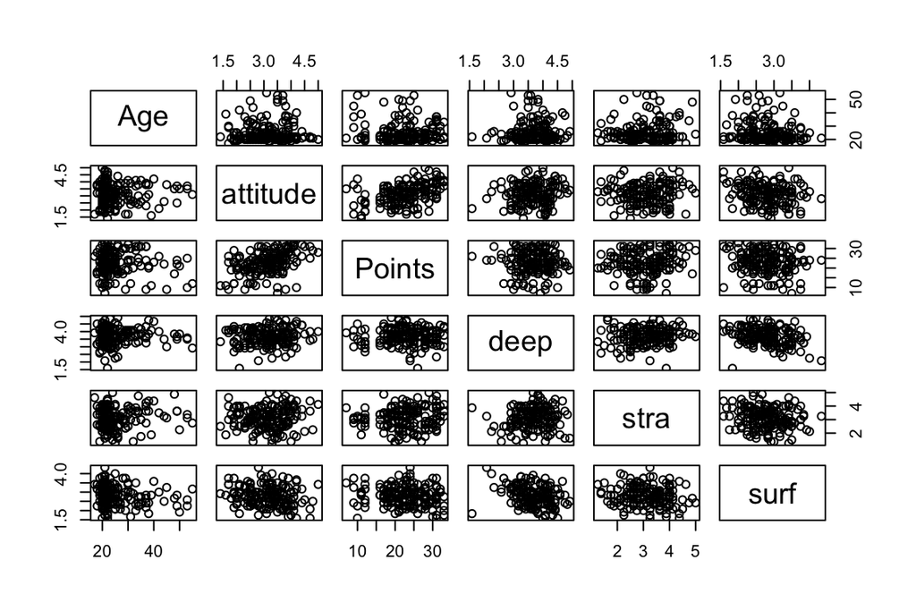

```r
pairs(data[,-4])
```

There is also an imbalance in the number of males and females in the survey.

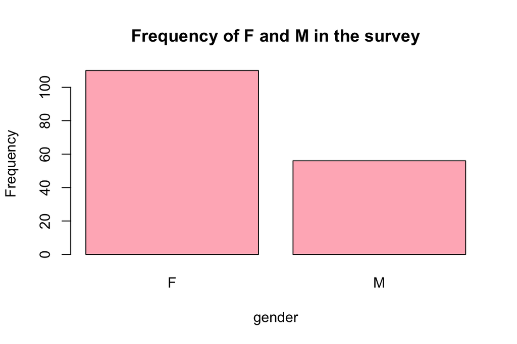

```r
barplot(table(data$gender), main="Frequency of F and M in the survey",xlab="gender", ylab="Frequency",col="lightpink")
```

Theres also a wide range of individuals in this survey from 17 to 55 and the most freq is 21.

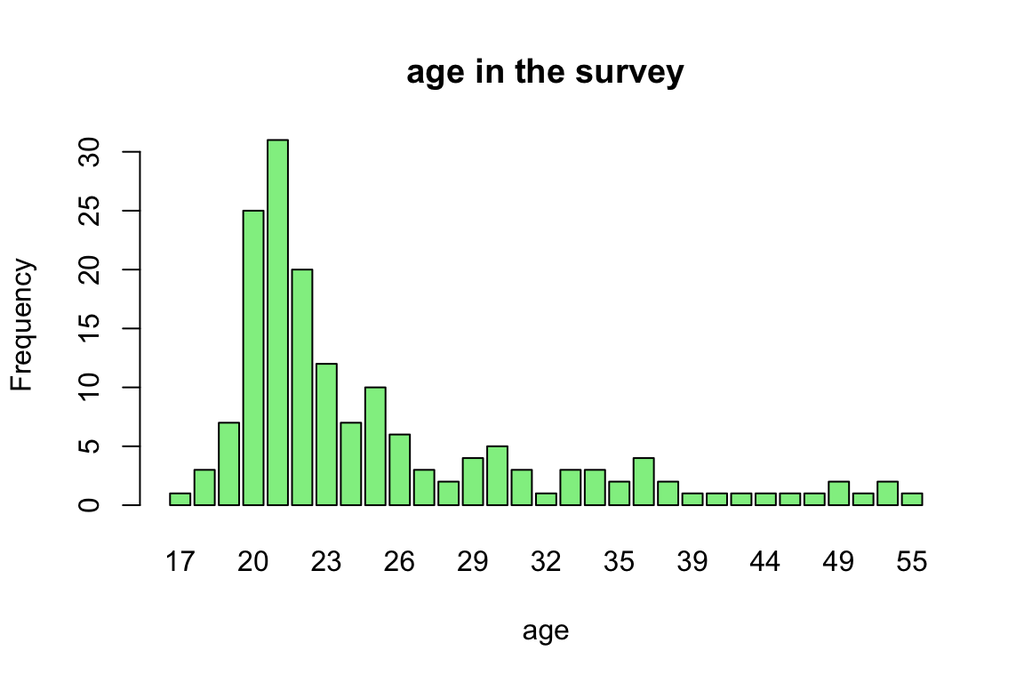

```r
barplot(table(data$Age), main="age in the survey",xlab="age", ylab="Frequency",col="lightgreen")
```

This is a good positive linear relationship between attitude and points and weaker between other variables and points( some negative– red circles).

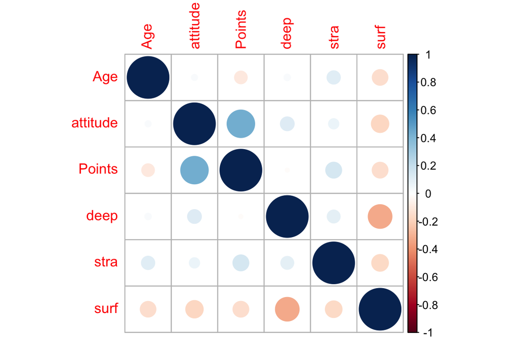

```r
M = cor(data[,-4])
corrplot::corrplot(M)
```

Now, we can build a linear regression model with some interesting variables. I have chosen attitude, stra and surf based on the correlation plot from above. Based on the summary, only attitude seems to be important predictor( based on the p value from the t statistic of 5.91 and comes from the estimate 3.3952 divided by the se error of 0.5741) and others are not significant in terms of p values. For example, surf has a p value of 0.46 so thats super insignificant. We will remove it and reformulate the model. In this lm1 model, the R2 is 0.192 which means that these variables only explain 19.2% of the variablity in points which is not very good.

The coefficient of attittude can be interpreted as : as an increase of 1 unit in attitude results in an increase of exam points by 3.39 units if other variables are held constant.

```r
lm1=lm(Points ~ stra + attitude + surf, data = data)
summary(lm1)
```

```
##
## Call:
## lm(formula = Points ~ stra + attitude + surf, data = data)
##
## Residuals:
##      Min       1Q   Median       3Q      Max
## -17.1550  -3.4346   0.5156   3.6401  10.8952
##
## Coefficients:
##             Estimate Std. Error t value Pr(>|t|)
## (Intercept)  11.0171     3.6837   2.991  0.00322 **
## stra          0.8531     0.5416   1.575  0.11716
## attitude      3.3952     0.5741   5.913 1.93e-08 ***
## surf         -0.5861     0.8014  -0.731  0.46563
## ---
## Signif. codes:  0 '***' 0.001 '**' 0.01 '*' 0.05 '.' 0.1 ' ' 1
##
## Residual standard error: 5.296 on 162 degrees of freedom
## Multiple R-squared:  0.2074, Adjusted R-squared:  0.1927
## F-statistic: 14.13 on 3 and 162 DF,  p-value: 3.156e-08
```

```r
lm2=lm(Points ~ stra + attitude , data = data)
summary(lm2)
```

```
##
## Call:
## lm(formula = Points ~ stra + attitude, data = data)
##
## Residuals:
##      Min       1Q   Median       3Q      Max
## -17.6436  -3.3113   0.5575   3.7928  10.9295
##
## Coefficients:
##             Estimate Std. Error t value Pr(>|t|)
## (Intercept)   8.9729     2.3959   3.745  0.00025 ***
## stra          0.9137     0.5345   1.709  0.08927 .
## attitude      3.4658     0.5652   6.132 6.31e-09 ***
## ---
## Signif. codes:  0 '***' 0.001 '**' 0.01 '*' 0.05 '.' 0.1 ' ' 1
##
## Residual standard error: 5.289 on 163 degrees of freedom
## Multiple R-squared:  0.2048, Adjusted R-squared:  0.1951
## F-statistic: 20.99 on 2 and 163 DF,  p-value: 7.734e-09
```

If we remove it again( if we only want really signif predictors), the r2 goes down to 0.18 so we better keep it. This means only 18% of the variability

```r
lm3=lm(Points ~ attitude , data = data)
summary(lm3)
```

```
##
## Call:
## lm(formula = Points ~ attitude, data = data)
##
## Residuals:
##      Min       1Q   Median       3Q      Max
## -16.9763  -3.2119   0.4339   4.1534  10.6645
##
## Coefficients:
##             Estimate Std. Error t value Pr(>|t|)
## (Intercept)  11.6372     1.8303   6.358 1.95e-09 ***
## attitude      3.5255     0.5674   6.214 4.12e-09 ***
## ---
## Signif. codes:  0 '***' 0.001 '**' 0.01 '*' 0.05 '.' 0.1 ' ' 1
##
## Residual standard error: 5.32 on 164 degrees of freedom
## Multiple R-squared:  0.1906, Adjusted R-squared:  0.1856
## F-statistic: 38.61 on 1 and 164 DF,  p-value: 4.119e-09
```

Based on the diagnostic plots we can see if our model is good. 1. the residuals vs fitted plot: we would expect to see random points/residuals which means that the model is able to capture the overarching trend in the data. if we were to see some shape( for example a parabola) we would determine that the the linear model does not capture the data well. It is a good fit if the red line (showing the mean of the data points) is close to the horizontal gray dotted line.  
2. The QQ plot: these points should be on the diagonal which means the residuals are normally distributed and the pvalues and SE are reliable. small deviations from this line are not a problem.  
3.standardized residuals vs leverage: these points should not be out of the cooks distance of 1. otherwise these would be high influence points which could affect the slope and the estimates of the lm model would not be reliable.

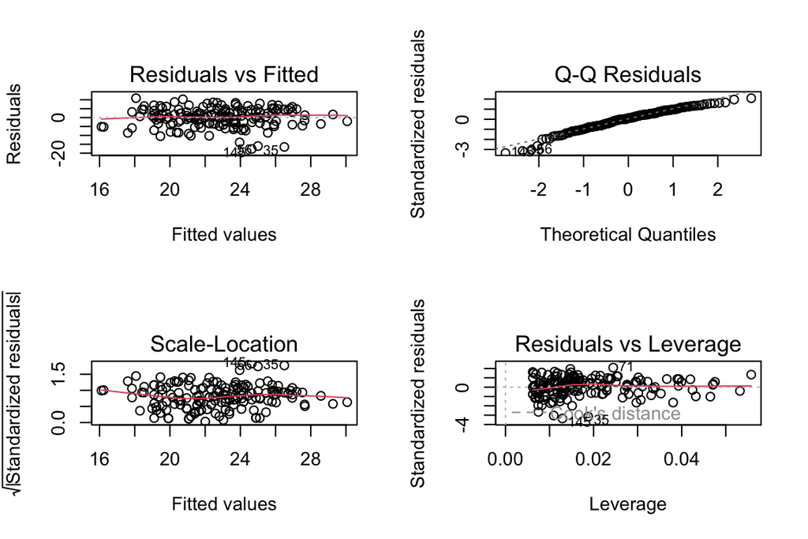

```r
par(mfrow=c(2,2))
plot(lm2)
```

# Chapter 3 Logistic Regression

```r
library(ggplot2)
library(ggpubr)
library(janitor)
library(caret)
library(readr)
library(tidyr)
library(dplyr)
```

Welcome to this weeks learning exercise where we look into cross validation and logistic regression!

This weeks data is from a questionnare on student performance with an emphasis on the effect of alcohol. There are 2 parts to this analysis:

- Data Wrangling: Join 2 datasets together to form the alko_data.csv.
- Data Analysis: Study the relationship between high/low alcohol consumption and other variables.

## Part 1: Data Wrangling

We joined 2 datasets together to form the basis for this analysis. Please see R script **./data/create_alc.R” for more information.

```r
alko=read_csv("./data/alko_data.csv")
str(alko)
```

```
## spc_tbl_ [370 × 35] (S3: spec_tbl_df/tbl_df/tbl/data.frame)
##  $ school    : chr [1:370] "GP" "GP" "GP" "GP" ...
##  $ sex       : chr [1:370] "F" "F" "F" "F" ...
##  $ age       : num [1:370] 18 17 15 15 16 16 16 17 15 15 ...
##  $ address   : chr [1:370] "U" "U" "U" "U" ...
##  $ famsize   : chr [1:370] "GT3" "GT3" "LE3" "GT3" ...
##  $ Pstatus   : chr [1:370] "A" "T" "T" "T" ...
##  $ Medu      : num [1:370] 4 1 1 4 3 4 2 4 3 3 ...
##  $ Fedu      : num [1:370] 4 1 1 2 3 3 2 4 2 4 ...
##  $ Mjob      : chr [1:370] "at_home" "at_home" "at_home" "health" ...
##  $ Fjob      : chr [1:370] "teacher" "other" "other" "services" ...
##  $ reason    : chr [1:370] "course" "course" "other" "home" ...
##  $ guardian  : chr [1:370] "mother" "father" "mother" "mother" ...
##  $ traveltime: num [1:370] 2 1 1 1 1 1 1 2 1 1 ...
##  $ studytime : num [1:370] 2 2 2 3 2 2 2 2 2 2 ...
##  $ schoolsup : chr [1:370] "yes" "no" "yes" "no" ...
##  $ famsup    : chr [1:370] "no" "yes" "no" "yes" ...
##  $ activities: chr [1:370] "no" "no" "no" "yes" ...
##  $ nursery   : chr [1:370] "yes" "no" "yes" "yes" ...
##  $ higher    : chr [1:370] "yes" "yes" "yes" "yes" ...
##  $ internet  : chr [1:370] "no" "yes" "yes" "yes" ...
##  $ romantic  : chr [1:370] "no" "no" "no" "yes" ...
##  $ famrel    : num [1:370] 4 5 4 3 4 5 4 4 4 5 ...
##  $ freetime  : num [1:370] 3 3 3 2 3 4 4 1 2 5 ...
##  $ goout     : num [1:370] 4 3 2 2 2 2 4 4 2 1 ...
##  $ Dalc      : num [1:370] 1 1 2 1 1 1 1 1 1 1 ...
##  $ Walc      : num [1:370] 1 1 3 1 2 2 1 1 1 1 ...
##  $ health    : num [1:370] 3 3 3 5 5 5 3 1 1 5 ...
##  $ failures  : num [1:370] 0 0 2 0 0 0 0 0 0 0 ...
##  $ paid      : chr [1:370] "no" "no" "yes" "yes" ...
##  $ absences  : num [1:370] 5 3 8 1 2 8 0 4 0 0 ...
##  $ G1        : num [1:370] 2 7 10 14 8 14 12 8 16 13 ...
##  $ G2        : num [1:370] 8 8 10 14 12 14 12 9 17 14 ...
##  $ G3        : num [1:370] 8 8 11 14 12 14 12 10 18 14 ...
##  $ alko_use  : num [1:370] 1 1 2.5 1 1.5 1.5 1 1 1 1 ...
##  $ high_use  : logi [1:370] FALSE FALSE TRUE FALSE FALSE FALSE ...
##  - attr(*, "spec")=
##   .. cols(
##   ..   school = col_character(),
##   ..   sex = col_character(),
```

[output cut: 20 more lines]

```
##   ..   freetime = col_double(),
##   ..   goout = col_double(),
##   ..   Dalc = col_double(),
##   ..   Walc = col_double(),
##   ..   health = col_double(),
##   ..   failures = col_double(),
##   ..   paid = col_character(),
##   ..   absences = col_double(),
##   ..   G1 = col_double(),
##   ..   G2 = col_double(),
##   ..   G3 = col_double(),
##   ..   alko_use = col_double(),
##   ..   high_use = col_logical()
##   .. )
##  - attr(*, "problems")=<externalptr>
```

From this we can see the structure of the data with 370 rows and 35 variables. These variables are printed below.

```r
colnames(alko)
```

```
##  [1] "school"     "sex"        "age"        "address"    "famsize"
##  [6] "Pstatus"    "Medu"       "Fedu"       "Mjob"       "Fjob"
## [11] "reason"     "guardian"   "traveltime" "studytime"  "schoolsup"
## [16] "famsup"     "activities" "nursery"    "higher"     "internet"
## [21] "romantic"   "famrel"     "freetime"   "goout"      "Dalc"
## [26] "Walc"       "health"     "failures"   "paid"       "absences"
## [31] "G1"         "G2"         "G3"         "alko_use"   "high_use"
```

The original source of the data is here: https://www.archive.ics.uci.edu/dataset/320/student+performance. This data was merged from 2 datasets from secondary schools in 2 Portuguese schools. The variables include those like( i will not list them all):  
* student grades(G1,G2,G3).

- guardian - student’s guardian (nominal: ‘mother’, ‘father’ or ‘other’).
- Dalc - workday alcohol consumption (numeric: from 1 - very low to 5 - very high).
- Walc - weekend alcohol consumption (numeric: from 1 - very low to 5 - very high).
- absences - number of school absences (numeric: from 0 to 93).

The two original datasets consist of data from 2 classes: Math (mat) and Portuguese(por) which were merged into one. Originally, there were 33 variables but we construct 2 more:

- alko_use as the average of the answers related to weekday and weekend alcohol consumption.
- logical data TRUE for students for which ‘alko_use’ is greater than 2 (and FALSE otherwise.

```r
#alko1=read_csv("https://raw.githubusercontent.com/KimmoVehkalahti/Helsinki-Open-Data-Science/master/datasets/alc.csv")
#dim(alko1) ## sanity check that the datasets are the same and the data wrangling was successfull
```

## Part 2: Analysis

The purpose now is to study the relationships between high/low alcohol consumption and some of the other variables in the data. We choose 4 interesting variables and look at their relationship with **high_use**. * AGE: I expect more heavy drinkers in older students.

- GOOUT: Influence and peer pressure heavily associated with drinking in teenagers.
- ABSENCES: More school absence with high alcohol use (hungover recovery).
- G3: Higher grades for those that don’t drink.

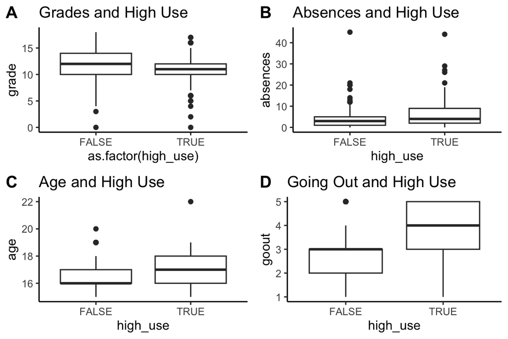

```r
a=ggplot(alko, aes(x = as.factor(high_use), y = G3))+geom_boxplot() + ylab("grade")+theme_classic()+ggtitle("Grades and High Use")
b=ggplot(alko, aes(x = high_use, y = absences))+geom_boxplot() + ylab("absences")+theme_classic()+ggtitle("Absences and High Use")
c=ggplot(alko, aes(x = high_use, y = age))+geom_boxplot() + ylab("age")+theme_classic()+
    ggtitle("Age and High Use")
d=ggplot(alko, aes(x = high_use, y = goout))+geom_boxplot() + ylab("goout")+theme_classic()+
    ggtitle("Going Out and High Use")
ggarrange(a, b, c, d,labels = c("A", "B", "C", "D"),ncol = 2, nrow = 2)
```

From these plots we can see that students that do not drink(or are heavy drinkers) have higher grades,less absences, younger, and dont go out as much(sadly). We can also look at cross tabulations but I dont find them useful as a visual aid– to much numbers.

```r
tabyl(alko, famrel, alko_use, high_use)
```

```
## $`FALSE`
##  famrel  1 1.5  2 2.5 3 3.5 4 4.5 5
##       1  2   2  2   0 0   0 0   0 0
##       2  6   1  2   0 0   0 0   0 0
##       3 17  12 10   0 0   0 0   0 0
##       4 70  27 31   0 0   0 0   0 0
##       5 45  21 11   0 0   0 0   0 0
##
## $`TRUE`
##  famrel 1 1.5 2 2.5  3 3.5 4 4.5 5
##       1 0   0 0   0  0   0 1   0 1
##       2 0   0 0   4  2   2 0   0 1
##       3 0   0 0  12  9   2 1   0 1
##       4 0   0 0  19 14   8 5   2 4
##       5 0   0 0   6  7   5 2   1 2
```

I will not subset the data just so it is easier to work with ( so i can use the **.**)

```r
alko_use_select=select(alko, absences, G3, age, goout, high_use)
```

Model with a logistic regression(because we have a logical outcome). We can see that absences and goout are the significant variables.

```r
glm.1=glm(high_use ~., data = alko_use_select, family = "binomial")
summary(glm.1)
```

```
##
## Call:
## glm(formula = high_use ~ ., family = "binomial", data = alko_use_select)
##
## Coefficients:
##             Estimate Std. Error z value Pr(>|z|)
## (Intercept) -3.77834    1.96186  -1.926  0.05412 .
## absences     0.07315    0.02237   3.270  0.00108 **
## G3          -0.04472    0.03923  -1.140  0.25435
## age          0.04563    0.11022   0.414  0.67890
## goout        0.70668    0.11917   5.930 3.03e-09 ***
## ---
## Signif. codes:  0 '***' 0.001 '**' 0.01 '*' 0.05 '.' 0.1 ' ' 1
##
## (Dispersion parameter for binomial family taken to be 1)
##
##     Null deviance: 452.04  on 369  degrees of freedom
## Residual deviance: 388.67  on 365  degrees of freedom
## AIC: 398.67
##
## Number of Fisher Scoring iterations: 4
```

The model coefficients

```r
coef(glm.1)
```

```
## (Intercept)    absences          G3         age       goout
## -3.77834234  0.07314823 -0.04471930  0.04562870  0.70667982
```

Calculate the log-odds ratio and confidence intervals. * For one unit increase in ‘absences’, there is a 1.07589001 increase in the log odds of having high consumption of alcohol. This is in line with my hypothesis that high alcohol consumptiion and absesnces are related.

```r
LOR=coef(glm.1) %>% exp
CI=confint(glm.1) %>% exp
cbind(LOR, CI)
```

```
##                    LOR        2.5 %   97.5 %
## (Intercept) 0.02286056 0.0004637374 1.033922
## absences    1.07589001 1.0312932049 1.127070
## G3          0.95626587 0.8852281993 1.032878
## age         1.04668570 0.8430071337 1.299954
## goout       2.02724925 1.6139414455 2.577757
```

To evaluate the model, we can look at the deviance

```r
with(glm.1, null.deviance - deviance)
```

```
## [1] 63.3708
```

```r
with(glm.1, pchisq(null.deviance - deviance, df.null - df.residual, lower.tail = FALSE))
```

```
## [1] 5.669695e-13
```

We have a significant chiseq so this model is better than a null model

We can use pseudo R2 with 0.14 which means only a small part of the deviance is explained by this model which isnt amazing. However, this isnt binded between 0 and 1 like R2

```r
library(pscl)
pR2(glm.1)
```

```
## fitting null model for pseudo-r2
```

```
##          llh      llhNull           G2     McFadden         r2ML         r2CU
## -194.3343924 -226.0197918   63.3707987    0.1401886    0.1574080    0.2231852
```

Using only significant variables with a 0.76 accuracy

```r
alko_use_select2=select(alko_use_select, high_use, absences, goout)
glm2=glm(high_use ~ absences + goout, data = alko_use_select2, family = "binomial")
summary(glm2)
```

```
##
## Call:
## glm(formula = high_use ~ absences + goout, family = "binomial",
##     data = alko_use_select2)
##
## Coefficients:
##             Estimate Std. Error z value Pr(>|z|)
## (Intercept) -3.63280    0.43792  -8.296  < 2e-16 ***
## absences     0.07632    0.02225   3.430 0.000602 ***
## goout        0.73380    0.11786   6.226 4.78e-10 ***
## ---
## Signif. codes:  0 '***' 0.001 '**' 0.01 '*' 0.05 '.' 0.1 ' ' 1
##
## (Dispersion parameter for binomial family taken to be 1)
##
##     Null deviance: 452.04  on 369  degrees of freedom
## Residual deviance: 390.30  on 367  degrees of freedom
## AIC: 396.3
##
## Number of Fisher Scoring iterations: 4
```

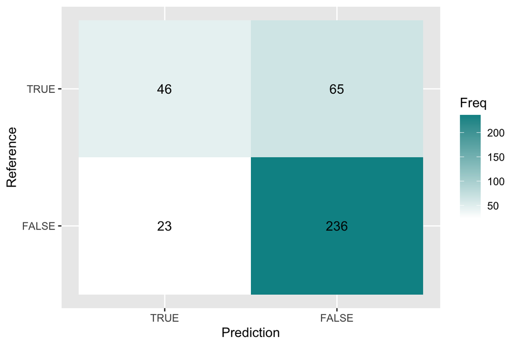

```r
alko_use_select2$predicted_values=predict(glm2, newdata = alko_use_select2, type = "response")
alko_use_select2$predicted_values=alko_use_select2$predicted_values > 0.5
cm=confusionMatrix(as.factor(alko_use_select2$predicted_values), as.factor(alko_use_select2$high_use), mode = "everything")

plt <- as.data.frame(cm$table)
plt$Prediction <- factor(plt$Prediction, levels=rev(levels(plt$Prediction)))

ggplot(plt, aes(Prediction,Reference, fill= Freq)) +
        geom_tile() + geom_text(aes(label=Freq)) +
        scale_fill_gradient(low="white", high="#009194")
```

```r
## (46+236)/370=0.76
```

Random guessing with 0.48 accuracy which is worse

```r
set.seed(1)
high_use_random=ifelse(rbinom(370, 1, 0.5)==1,"TRUE","FALSE")
table(high_use_random, alko_use_select2$high_use)
```

```
##
## high_use_random FALSE TRUE
##           FALSE   134   65
##           TRUE    125   46
```

```r
##(134+46)/370
```

Then we can start generalizing with a 10 fold cross valiation

```r
train_=trainControl(method = "cv", number = 10)

cv =train(factor(high_use) ~.,
               data = alko_use_select2,
               trControl = train_,
               method = "glm",
               family=binomial())
cv
```

```
## Generalized Linear Model
##
## 370 samples
##   3 predictor
##   2 classes: 'FALSE', 'TRUE'
##
## No pre-processing
## Resampling: Cross-Validated (10 fold)
## Summary of sample sizes: 333, 333, 334, 333, 332, 333, ...
## Resampling results:
##
##   Accuracy   Kappa
##   0.7622768  0.3596589
```

```r
cv1 =train(factor(high_use) ~ age + famrel + goout + health, data = alko,
               trControl = train_,
               method = "glm",
               family=binomial())
cv1
```

```
## Generalized Linear Model
##
## 370 samples
##   4 predictor
##   2 classes: 'FALSE', 'TRUE'
##
## No pre-processing
## Resampling: Cross-Validated (10 fold)
## Summary of sample sizes: 333, 333, 333, 333, 333, 333, ...
## Resampling results:
##
##   Accuracy   Kappa
##   0.7459459  0.3132404
```

Lets try more models: we start with a full model. This consists of 34 predictors and from now we know there will definitely be overfitting.

```r
 cvfull=train(factor(high_use) ~ .,
               data = alko,
               trControl = train_,
               method = "glm",
               family=binomial())
cvfull
```

```
## Generalized Linear Model
##
## 370 samples
##  34 predictor
##   2 classes: 'FALSE', 'TRUE'
##
## No pre-processing
## Resampling: Cross-Validated (10 fold)
## Summary of sample sizes: 333, 333, 333, 334, 333, 333, ...
## Resampling results:
##
##   Accuracy  Kappa
##   1         1
```

And thats exactly what we get. The output says that glm didnt converge so the results are misleading. We get an accuracy of 100% which is suspicious and I wouldnt trust it. We can try another model with half the predictors(17 random pred).

```r
index=sample(34,17,replace=FALSE)
cvhalf=train(factor(high_use) ~ .,
               data = alko[,c(index,35)],
               trControl = train_,
               method = "glm",
               family=binomial())
cvhalf
```

```
## Generalized Linear Model
##
## 370 samples
##  17 predictor
##   2 classes: 'FALSE', 'TRUE'
##
## No pre-processing
## Resampling: Cross-Validated (10 fold)
## Summary of sample sizes: 333, 333, 333, 334, 333, 333, ...
## Resampling results:
##
##   Accuracy  Kappa
##   1         1
```

But when we use these 2, we get overfitting.

```r
cvstwo=train(factor(high_use) ~ Walc+Dalc,
               data = alko,
               trControl = train_,
               method = "glm",
               family=binomial())
cvstwo
```

```
## Generalized Linear Model
##
## 370 samples
##   2 predictor
##   2 classes: 'FALSE', 'TRUE'
##
## No pre-processing
## Resampling: Cross-Validated (10 fold)
## Summary of sample sizes: 333, 333, 333, 334, 333, 332, ...
## Resampling results:
##
##   Accuracy  Kappa
##   1         1
```

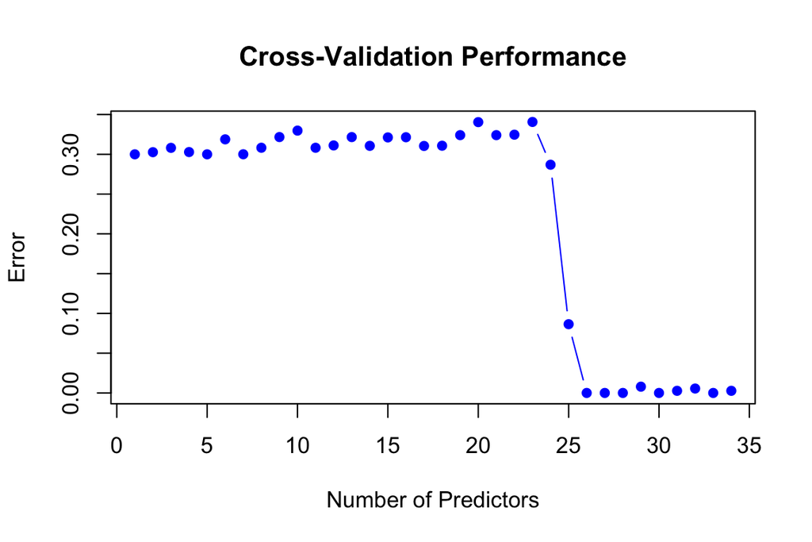

```r
cv_logistic =function(num_predictors) {
    if(num_predictors> 34){
        break
    }
    predictors=names(alko)[c(1:(num_predictors))]
    form= as.formula(paste("as.factor(high_use) ~", paste(predictors, collapse = " + ")))

    model=train(form,
                 data = alko,
                 trControl = train_,
                 method = "glm",
                 family = binomial())

  return(error = model$results$Accuracy)
}

num_predictors_range =seq(ncol(alko) - 1, 1, by = -1)
cv_results=sapply(num_predictors_range, cv_logistic)

plot(num_predictors_range,1-cv_results, type = 'b', col = 'blue', pch = 16, xlab = 'Number of Predictors', ylab = 'Error', main = 'Cross-Validation Performance')
```